# Test a Perceptual Phenomenon

### Analyzing the Stroop Effect

Perform the analysis in the space below. Remember to follow [the instructions](https://docs.google.com/document/d/1-OkpZLjG_kX9J6LIQ5IltsqMzVWjh36QpnP2RYpVdPU/pub?embedded=True) and review the [project rubric](https://review.udacity.com/#!/rubrics/71/view) before submitting. Once you've completed the analysis and write-up, download this file as a PDF or HTML file, upload that PDF/HTML into the workspace here (click on the orange Jupyter icon in the upper left then Upload), then use the Submit Project button at the bottom of this page. This will create a zip file containing both this .ipynb doc and the PDF/HTML doc that will be submitted for your project.

(1) What is the independent variable? What is the dependent variable?

**Independent Variable** - is the congruent words condition (where the words being displayed are color words whose names match the colors in which they are printed) and the incongruent words condition (where the words displayed are color words whose names do not match the colors in which they are printed)

**Dependent Variable** - is the time it takes to name the ink colors in equally-sized lists.

(2) What is an appropriate set of hypotheses for this task? Specify your null and alternative hypotheses, and clearly define any notation used. Justify your choices.

**Null Hypothesis** - The mean difference observed between the response time for the two groups with equally-sized lists, that is Congruent words and Incongruent words, is Zero.

$$H0: μ1 = μ2$$

**Alternative Hypothesis** - The mean difference observed between the response time for the two groups with equally-sized lists, that is Congruent words and Incongruent words, is NOT Zero.

$$H1: μ1 ≠ μ2$$

A **dependent t-test** is carried out, which compares the mean of the paired groups. Similar subjects are tested for both Congruent and Incongruent words.

As stated above, the Null Hypothesis suggests that there is no statistically significant difference between the mean times taken to name ink color. If the result obtained is significant it means, we can accept the alternative or reject the null.

(3) Report some descriptive statistics regarding this dataset. Include at least one measure of central tendency and at least one measure of variability. The name of the data file is 'stroopdata.csv'.

```python
# Perform the analysis here
import pandas as pd
import matplotlib.pyplot as plt
import seaborn as sns
from scipy import stats
import scipy.stats

%matplotlib inline

df = pd.read_csv('stroopdata.csv')
df
```

|  | Congruent | Incongruent |
| --- | --- | --- |
| 0 | 12.079 | 19.278 |
| 1 | 16.791 | 18.741 |
| 2 | 9.564 | 21.214 |
| 3 | 8.630 | 15.687 |
| 4 | 14.669 | 22.803 |
| 5 | 12.238 | 20.878 |
| 6 | 14.692 | 24.572 |
| 7 | 8.987 | 17.394 |
| 8 | 9.401 | 20.762 |
| 9 | 14.480 | 26.282 |
| 10 | 22.328 | 24.524 |
| 11 | 15.298 | 18.644 |
| 12 | 15.073 | 17.510 |
| 13 | 16.929 | 20.330 |
| 14 | 18.200 | 35.255 |
| 15 | 12.130 | 22.158 |
| 16 | 18.495 | 25.139 |
| 17 | 10.639 | 20.429 |
| 18 | 11.344 | 17.425 |
| 19 | 12.369 | 34.288 |
| 20 | 12.944 | 23.894 |
| 21 | 14.233 | 17.960 |
| 22 | 19.710 | 22.058 |
| 23 | 16.004 | 21.157 |

```python
#Check if data is normal
##A p-value of 0.04636 isn't enough evidence to assume that our data isn't normal
print ("Town 1 Shapiro‐Wilks p‐value", scipy.stats.shapiro(df)[1])
```

```
Town 1 Shapiro‐Wilks p‐value 0.04636985808610916
```

```python
#Statistics summary
df.describe()
```

|  | Congruent | Incongruent |
| --- | --- | --- |
| count | 24.000000 | 24.000000 |
| mean | 14.051125 | 22.015917 |
| std | 3.559358 | 4.797057 |
| min | 8.630000 | 15.687000 |
| 25% | 11.895250 | 18.716750 |
| 50% | 14.356500 | 21.017500 |
| 75% | 16.200750 | 24.051500 |
| max | 22.328000 | 35.255000 |

### Central Tendency (Mean)

**Congruent**= 14.0511 and **Incongruent** = 22.0159

### Measure of Variability (Standard Deviation or std)

**Congruent** = 3.5594 and **Incongruent** = 4.7971

*Summary: Response time for incongruent words is higher than the congruent words as given by the central tendency and the measure of variability.*

(4) Provide one or two visualizations that show the distribution of the sample data. Write one or two sentences noting what you observe about the plot or plots.

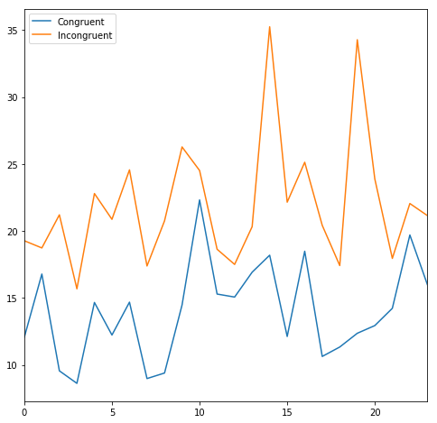

```python
# Build the visualizations here
#The first one is a line graph, which shows that 'congruent' group has steadier progression in the average population of time taken to name the ink colors
df.plot (kind = 'line', figsize = (8,8));
```

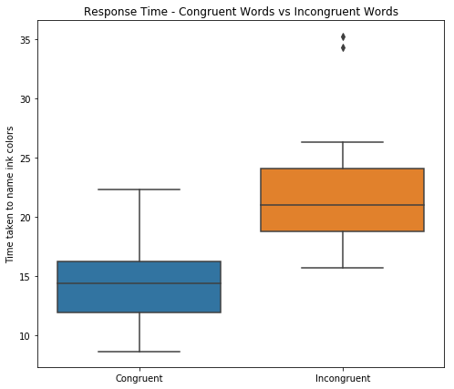

```python
#The second visualiztion is a box plot, used to identify outliers and comparing distributions
plt.figure(figsize=(8, 7))
sns.boxplot(data=df[['Congruent', 'Incongruent']], orient="v");
plt.ylabel("Time taken to name ink colors");
plt.title("Response Time - Congruent Words vs Incongruent Words");
```

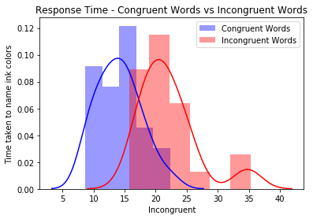

```python
#show the distribution using distplot to fit a parametric distribution
sns.distplot(df['Congruent'], color = "b", label = "Congruent Words");
sns.distplot(df['Incongruent'], color = "r", label = "Incongruent Words");
plt.legend();
plt.ylabel("Time taken to name ink colors");
plt.title("Response Time - Congruent Words vs Incongruent Words");
```

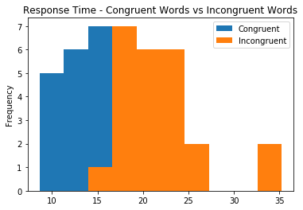

```python
#show distribution using a histogram
df.plot(kind='hist');
plt.title("Response Time - Congruent Words vs Incongruent Words");
```

*As shown by the visualizations above, the distribution of time taken for Congruent words is lesser than the time taken for Incongruent words. Additionally, the response time for each participant is greater for Incongruent words than for Congruent words. The results from the descriptive statitstics summary also resonates with the above results as the mean and median values for Incongruent words is greater than Congruent words.*

(5) Now, perform the statistical test and report your results. What is your confidence level or Type I error associated with your test? What is your conclusion regarding the hypotheses you set up? Did the results match up with your expectations? **Hint:** Think about what is being measured on each individual, and what statistic best captures how an individual reacts in each environment.

```python
#Manipulate Data
df.shape, df.columns
```

```
((24, 2), Index(['Congruent', 'Incongruent'], dtype='object'))
```

t-statistics can be calculated using the equation of Signal to Noise ratio (Average Difference to Measure of Variability):

$$t_{statistic} = \frac{\bar x_{D} - \mu_0}{s_{D}/\sqrt{n}}$$

The degreesOfFreedom can be obtained using: the size of data minus 1. (n -1)

Significance level to be used is 0.05 (5% chance of making Type I error).

```python
from math import sqrt
n = 24
### Hypothesis will be tested using two-tailed test with a significance level of 0.05 (i.e., 0.025 will be allocated on each tail)
degreesOfFreedom = n - 1
sdf = 0.05 #significance difference
confidence_level = 1 - sdf


################################################################################
#To calculate the t_statistics, find the mean of the difference
difference_mean = (df['Congruent'] - df['Incongruent']).mean()
#To calculate the t_statistics, find the mean of deviation
difference_deviation = (df['Congruent'] - df['Incongruent']).std()
#The t-value is:
t_val = difference_mean/(difference_deviation/float(sqrt(24)))
print("Signal to Noise ratio or the t_statistics is: {:.4f}" .format(t_val))
```

```
Signal to Noise ratio or the t_statistics is: -8.0207
```

```python
#Critical value at a significance level of 0.05
# 0.025 is used because the significance level is 0.05 and we are doing a two tailed test hence, 0.05/2 = 0.025
print ("Critical value is: {:.4f}, {:.4f}".format(stats.t.ppf(1-0.975, degreesOfFreedom), stats.t.ppf(1-0.025, degreesOfFreedom)))
```

```
Critical value is: -2.0687, 2.0687
```

**The t_statistics value is used to accept or reject the null hypothesis. Given the critical value above, which is greater than the t-statistics value there is less than 5% probability of finding a t_stat as extreme as the one we have.**

```python
#Perform t-test on the two scores to find the p-value
stats.ttest_rel(df.Congruent, df.Incongruent)
```

```
Ttest_relResult(statistic=-8.020706944109957, pvalue=4.1030005857111781e-08)
```

*Our p-value is lower than our significance level of 0.05(alpha = 5%= 0.05). Therefore, we reject our null hypothesis. Thus, incongruent and congruent group has different average population time to complete tasks.*

(6) Optional: What do you think is responsible for the effects observed? Can you think of an alternative or similar task that would result in a similar effect? Some research about the problem will be helpful for thinking about these two questions!

**In my opinion, the fact that words are our primary means of communication before we even go to school is responsible for the effects observed. Our brain has years of training in identifying words, hence it takes lesser time to respond to words than colors.**

Another similar effect would be *Reverse Stroop Effect*.

### REFERENCE

1. Analytics Vidhya or Your Guide to Master Hypothesis Testing in Statistics (https://www.analyticsvidhya.com/blog/2015/09/hypothesis-testing-explained/)
2. Cumulative Distribution Functions and Percentile Point Functions (http://eric.univ-lyon2.fr/~ricco/tanagra/fichiers/en_Tanagra_Calcul_P_Value.pdf)
3. Statistics HowTo (http://www.statisticshowto.com/probability-and-statistics/find-critical-values/)
4. Stroop Effect (https://en.wikipedia.org/wiki/Stroop_effect#Warped_words)
5. Documentation (https://docs.scipy.org/doc/scipy/reference/tutorial/stats.html and https://docs.scipy.org/doc/scipy-0.16.1/reference/generated/scipy.stats.ttest_rel.html)
6. Python for Data Science (https://pythonfordatascience.org/paired-samples-t-test-python/)
7. Pyto Learn (http://pytolearn.csd.auth.gr/d1-hyptest/12/ttest-paired.html)
8. GitHub